[figure not shown]

[figure not shown]

# OA Clusters

### What are the aims of using non-supervised learning (or clustering)?

Clustering data can be described as ‘the art of finding groups in data’. Classifying similar objects into groups is an important and natural human activity and a prominent part of science, history, government, education and marketing. In the past, clustering and categorising has usually been quite subjective, and down to the judgment of the researcher.

Larger and more complex data sets have seen the rise of automatic categorisation procedures, which is where clustering techniques fit in to the world of data science. The main reasons for using this kind of technique are:

- identify distinct groups within a data set
- as an extension of exploratory data analysis
- gain insight into how the data and how variables relate to one another
- improve supervised/predictive analysis

In this project, each of the above are relevant.

Since its creation as a Roman city over 2000 years ago, London’s growth has been haphazard and random, compared to the more planned and gradual expansion of other cities. But even so, when we break up the boroughs by OA, can we see distinct clusters of neighbourhoods, like Victorian terraces, postwar tower blocks, suburban cul-de-sacs and modern blocks of flats?

Given that OAs are purely administrative inventions - can we see clusters like this emerge? Or is the data too noisy?

### Summary of data and aims of cluster analysis

At the moment, this data is only for Lewisham Council. I will be running the cluster on buildings data, which has been split into categories for type and age.

**Type**: Flat block | Converted Flats | House (detached/semi-detached) | Terraced house

**Age**: Victorian/pre-WW1 | Interwar | Postwar (1945-1979) | Modern (1980-)

For each OA, the percentage of addresses that fall into each of the above categories is calculated. The clusters are based on these variables. What we are looking for here is whether or not OAs fit into neat categories of building types.

This analysis is carried out using **k-means** clustering, where we need to specify the number of categories, then the algorithms find that number of categories in the data. We call this *unsupervised* learning, since we are not defining what the categories are.

Our first step therefore is to try and decide how many categories there are. A common way of doing is using the **elbow** method. See the next slide.

### Elbow Chart

[interactive chart not shown]

In the chart below, we run a kmeans cluster, where k is between 2 and 15. We are looking for an ‘elbow’. If the shape of the line is close to a right angle, where the joint of the ‘elbow’ is the optimum k for the kmeans cluster. If the line is a smoother curve, this suggests that any k will work, but there is not a natural set of clusters in the data.

### General

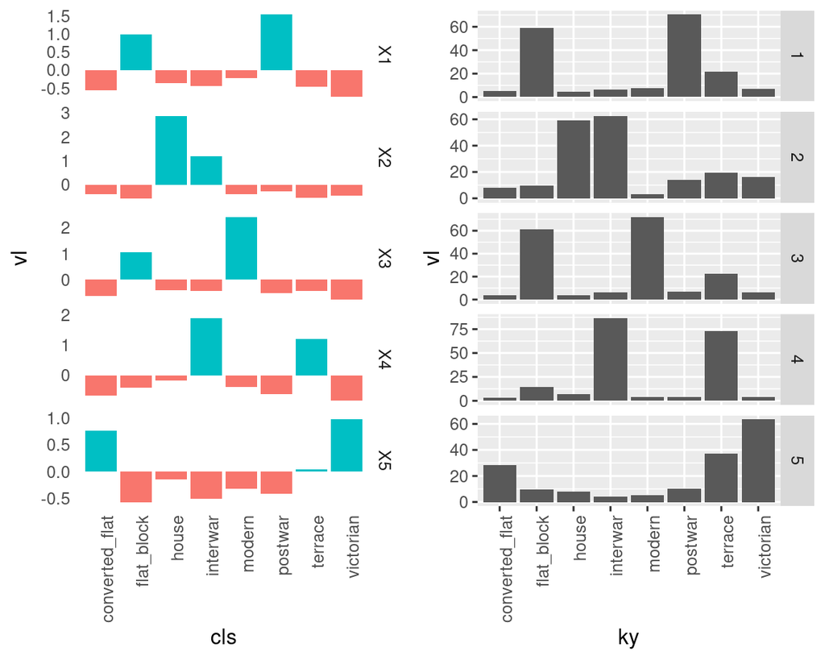

In the above example, the resulting five clusters, that are unevenly distributed.

### Silhouette plot to test how well defined the clusters are

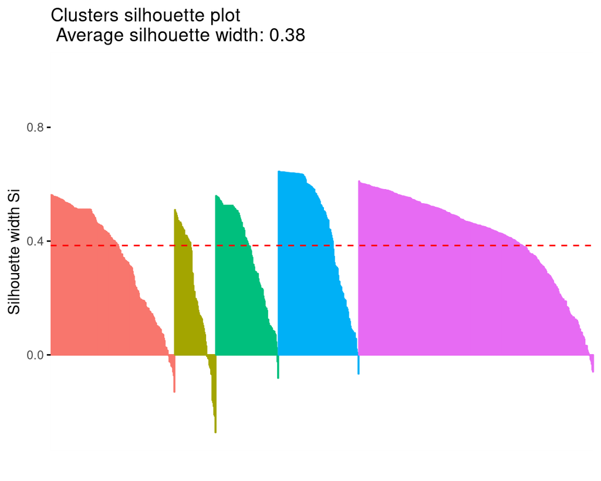

### Comparison of clusters against voter registration

[interactive chart not shown]

Each of the clusters has a different distribution compared to voter registration.

### Conclusion

The clustering here is not as well defined as we thought it might be. We think there are two main reasons for this:

1. Streets in London, develop gradually over time and sometimes less than orderly manner, especially compared to places like Paris.
2. OAs are a quite arbitrary boundaries, drawn up for administrative purposes not to reflect any kind of neighbourhood

The next stage is to see whether this clustering works any better for streets and other combinations of variables.